# MXB344 Week 4 Slides

14 August 2016

## Welcome

MXB344 Lecture 4

## Housekeeping

- Your first assignment is now live. Check you can push to your github repository!

## Recapping last week

Last week we:

- Discussed hypothesis tests available using the model deviance.
- Learned about 2 kinds of residuals: Deviance and Pearson.
- Introduced Poisson regression and the concept of exposure.

## Poisson Regression 2: Selection, Validation, Interpretation

## Hat matrix & Leverage

- Recall the Hat matrix from the normal linear model case:

\[H = X(X^{T}X)^{-1}X^{T}\]

from:

\[ \hat{B} = (X^{T}X)^{-1}X^{T}Y\]

Has useful properties:

- \(h_{ii}\) is called **leverage**.
  - Ranges between 0 and 1.
  - A measure of the observation's infleunce on the fit.
- \(var[\epsilon_{i}] = \sigma^{2}(1-h_{ii})\)

## Hat matrix & Leverage

- In GLMs the Hat matrix has a slightly different form:

\[H=X(X^{T}WX)^{-1}X^{T}W\]

Where \(W\) is introduced by the fitting procedure (We'll discuss later). It retains it's properties:

- We can use \(h_{ii}\) to standardise residuals. \(R = \sum \frac{r_{i}}{\sqrt{1-h_{ii}}}\)
- We can use \(h_{ii}\) to investiagte infulential points.
  - Actually we'll use **Cook's Distance** which is a function of \(h_{ii}\)

Further reading: [Cook's Distance](https://en.wikipedia.org/wiki/Cook%27s_distance), [Studentised Residuals](https://en.wikipedia.org/wiki/Studentized_residual), MAB624 Notes p132

## Putting it all Together: Poisson

- We're going to workthrough an example of working through a data analysis process to create fit and interpret Possion GLM The 'Explore' and 'Communicate' part:

[figure not shown]

From: [R for Data Science](http://r4ds.had.co.nz/introduction-1.html), *Hadley Wickham*

## Shipping Incident Data

```
##    type construction operation service incidents
## 1     A      1960-64   1960-74     127         0
## 2     A      1960-64   1975-79      63         0
## 3     A      1965-69   1960-74    1095         3
## 4     A      1965-69   1975-79    1095         4
## 5     A      1970-74   1960-74    1512         6
## 6     A      1970-74   1975-79    3353        18
## 7     A      1975-79   1975-79    2244        11
## 8     B      1960-64   1960-74   44882        39
## 9     B      1960-64   1975-79   17176        29
## 10    B      1965-69   1960-74   28609        58
```

## Shipping Incident Data

```r
sa <- ShipAccidents %>% filter(service > 0)

sa_full <- glm(data = sa,
                formula = incidents ~ type + construction +
                 operation,
                family = poisson(link="log"),
                offset = log(service)
              )

anova(sa_full, test="Chisq")
```

```
## Analysis of Deviance Table
##
## Model: poisson, link: log
##
## Response: incidents
##
## Terms added sequentially (first to last)
##
##
##              Df Deviance Resid. Df Resid. Dev  Pr(>Chi)
## NULL                            33    146.328
## type          4   55.439        29     90.889 2.629e-11 ***
## construction  3   41.298        26     49.591 5.653e-09 ***
## operation     1   10.628        25     38.963  0.001114 **
## ---
## Signif. codes:  0 '***' 0.001 '**' 0.01 '*' 0.05 '.' 0.1 ' ' 1
```

```r
summary(sa_full)
```

```
##
## Call:
## glm(formula = incidents ~ type + construction + operation, family = poisson(link = "log"),
##     data = sa, offset = log(service))
##
## Deviance Residuals:
##     Min       1Q   Median       3Q      Max
## -1.6770  -0.8312  -0.4818   0.5277   2.7901
##
## Coefficients:
##                     Estimate Std. Error z value Pr(>|z|)
## (Intercept)         -6.40288    0.21752 -29.435  < 2e-16 ***
## typeB               -0.54471    0.17761  -3.067  0.00216 **
## typeC               -0.68876    0.32903  -2.093  0.03632 *
## typeD               -0.07431    0.29056  -0.256  0.79815
## typeE                0.32053    0.23575   1.360  0.17396
## construction1965-69  0.69585    0.14966   4.650 3.33e-06 ***
## construction1970-74  0.81746    0.16984   4.813 1.49e-06 ***
## construction1975-79  0.44497    0.23324   1.908  0.05642 .
## operation1975-79     0.38386    0.11826   3.246  0.00117 **
## ---
## Signif. codes:  0 '***' 0.001 '**' 0.01 '*' 0.05 '.' 0.1 ' ' 1
##
## (Dispersion parameter for poisson family taken to be 1)
##
##     Null deviance: 146.328  on 33  degrees of freedom
## Residual deviance:  38.963  on 25  degrees of freedom
## AIC: 154.83
##
## Number of Fisher Scoring iterations: 5
```

## Model Summary

```
##
## Call:
## glm(formula = incidents ~ type + construction + operation, family = poisson(link = "log"),
##     data = sa, offset = log(service))
##
## Deviance Residuals:
##     Min       1Q   Median       3Q      Max
## -1.6770  -0.8312  -0.4818   0.5277   2.7901
##
## Coefficients:
##                     Estimate Std. Error z value Pr(>|z|)
## (Intercept)         -6.40288    0.21752 -29.435  < 2e-16 ***
## typeB               -0.54471    0.17761  -3.067  0.00216 **
## typeC               -0.68876    0.32903  -2.093  0.03632 *
## typeD               -0.07431    0.29056  -0.256  0.79815
## typeE                0.32053    0.23575   1.360  0.17396
## construction1965-69  0.69585    0.14966   4.650 3.33e-06 ***
## construction1970-74  0.81746    0.16984   4.813 1.49e-06 ***
## construction1975-79  0.44497    0.23324   1.908  0.05642 .
## operation1975-79     0.38386    0.11826   3.246  0.00117 **
## ---
## Signif. codes:  0 '***' 0.001 '**' 0.01 '*' 0.05 '.' 0.1 ' ' 1
##
## (Dispersion parameter for poisson family taken to be 1)
##
##     Null deviance: 146.328  on 33  degrees of freedom
## Residual deviance:  38.963  on 25  degrees of freedom
## AIC: 154.83
##
## Number of Fisher Scoring iterations: 5
```

## Analysis of Deviance

```r
anova(sa_full, test="Chisq")
```

```
## Analysis of Deviance Table
##
## Model: poisson, link: log
##
## Response: incidents
##
## Terms added sequentially (first to last)
##
##
##              Df Deviance Resid. Df Resid. Dev  Pr(>Chi)
## NULL                            33    146.328
## type          4   55.439        29     90.889 2.629e-11 ***
## construction  3   41.298        26     49.591 5.653e-09 ***
## operation     1   10.628        25     38.963  0.001114 **
## ---
## Signif. codes:  0 '***' 0.001 '**' 0.01 '*' 0.05 '.' 0.1 ' ' 1
```

What hypotheses can we test here?

## Residuals

```r
#Test of Scaled Residual Deviance against Saturated Model
pchisq(sa_full$deviance, df = sa_full$df.residual ,lower.tail = FALSE)
```

```
## [1] 0.03715884
```

```r
sum(residuals(sa_full, type="pearson")^2)
```

```
## [1] 42.44145
```

```r
sa_full$df.residual
```

```
## [1] 25
```

\(\sum\) Pearson residuals\(^2\) \(\ne N - P\)?

## Residual Plots

### Pearson

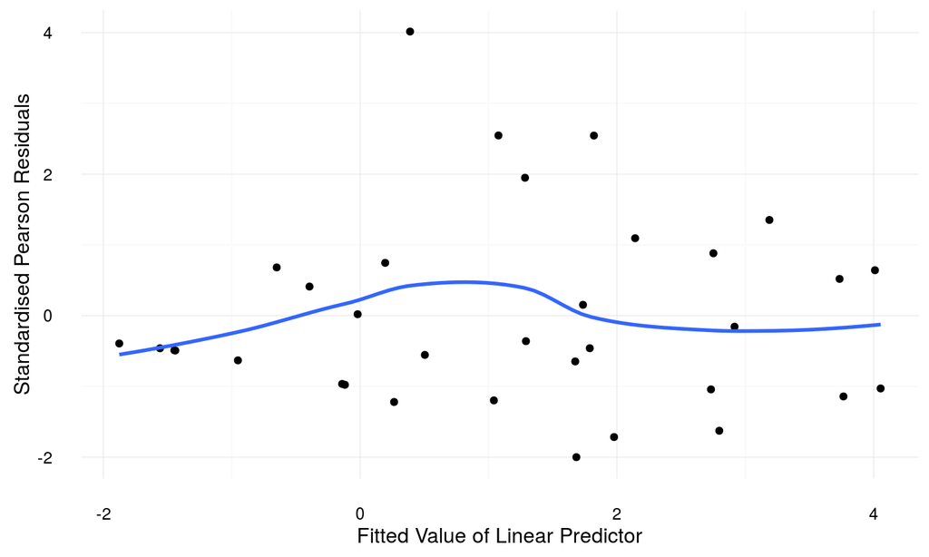

## Residual Plots

### Deviance

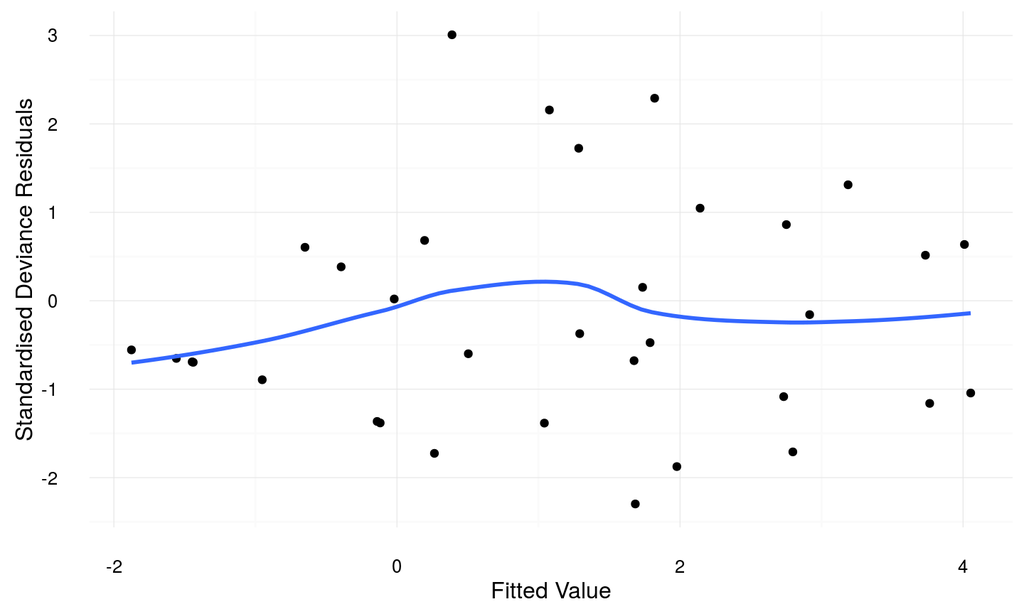

## Considering Influence

p136 MAB624 notes

- Cook's Distance is the influence measure of choice

\[\frac{(r^{P}_{i})^2}{(1-h_{ii})^2\phi} \frac{h_{ii}}{tr(H)}\]

- \(CD \ge 2\) is considered noteworthy.

## Cook's Distance plot

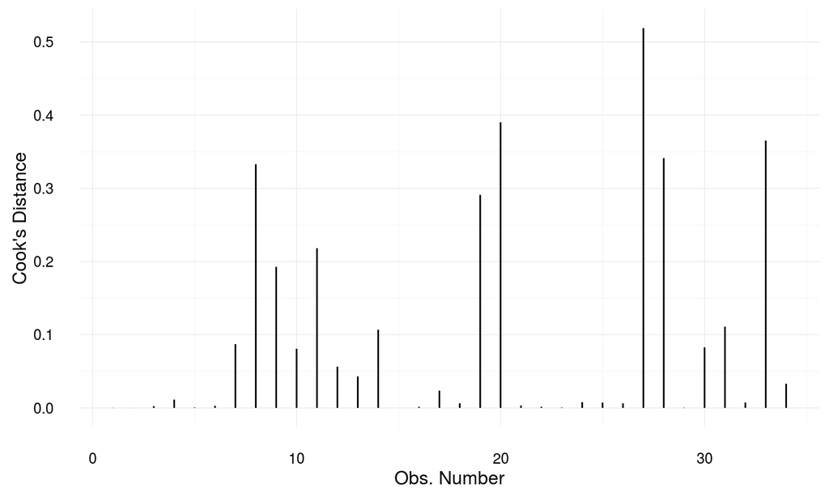

## Plotting Performance

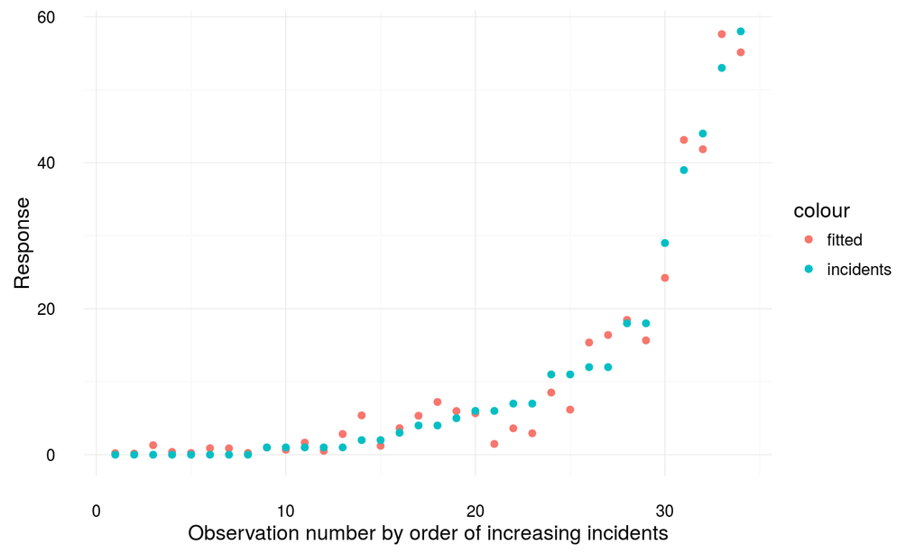

## Intepretation

```
##                  term    estimate std.error   statistic       p.value
## 1         (Intercept) -6.40287720 0.2175228 -29.4354321 1.934205e-190
## 2               typeB -0.54471145 0.1776135  -3.0668365  2.163372e-03
## 3               typeC -0.68876446 0.3290327  -2.0933009  3.632230e-02
## 4               typeD -0.07430914 0.2905578  -0.2557465  7.981466e-01
## 5               typeE  0.32052881 0.2357520   1.3596015  1.739561e-01
## 6 construction1965-69  0.69584550 0.1496562   4.6496267  3.325363e-06
## 7 construction1970-74  0.81745541 0.1698376   4.8131604  1.485620e-06
## 8 construction1975-79  0.44497065 0.2332391   1.9077875  5.641868e-02
## 9    operation1975-79  0.38385913 0.1182604   3.2458802  1.170881e-03
##   effect.lwr_ci      effect effect.upr_ci
## 1   0.001072329 0.001656784   0.002559786
## 2   0.406594713 0.580009119   0.827385520
## 3   0.260063393 0.502196169   0.969767369
## 4   0.519221502 0.928384649   1.659981439
## 5   0.859868983 1.377856191   2.207880177
## 6   1.486661622 2.005403922   2.705151482
## 7   1.612491164 2.264729684   3.180792961
## 8   0.978722089 1.560444393   2.487924539
## 9   1.158745910 1.467938641   1.859634485
```

## Effect Plot

[interactive chart not shown]

## Stating Effects

- When using the log link the exponentiated parameter estimates correspond to multiplicative effects on the rate.
- Given the previous example we might say:
  - *We estimate with 95% confidence that ships of type B have an incident rate between 1.2 and 2.4 times lower than ships of type A over an equal period, with all other factors held constant*.
  - **note:** 1/.41 = 2.4, 1/.83 =1.2
- Also common to express **Relative Rates** as percentages:
  - *We estimate with 95% confidence that ships constructed from 1965 to 1969 have an incident rate 49% to 171% higher than those constructed from 1960 to 1964, with all other factors held constant*.
- Communicating the uncertainty is hard, but *very* important.

## Poisson Regression

- That's the end of Poisson Regression. You now have all the tools you need to complete count data analysis with the Poisson GLM.
- For count data that is over-dispersed for Poisson, it is common to used the Negative Binomial likelihood instead of the quasipoisson.
  - Google 'Negative Binomial Regression'.
- Poisson regression is sensitive to 0s. Too many 0s or situations where 0s cannot occur create problems. In practice there are alternatives:
  - [Zero-Inflated Poisson distribution](http://www.ats.ucla.edu/stat/r/dae/zipoisson.htm), [Zero-Truncated Poisson distribution](http://www.ats.ucla.edu/stat/r/dae/ztp.htm)

## Binomial/Binary Regression

## Disambiguation: Binary Regression

- Binary regression assumes the \(Y_{i}\)s follow a Bernoulli distribution. By convention every response is either 0 or 1.
- Overwhelmingly, you will hear this referred to as **Logistic regression**.
  - This comes from the logit function which is the canonical link.
- This regression is probably the second most popular regression in use today after normal.
- Many interesting events can be modelled as Bernoulli:
  - Credit Risk, Survival, Win/Loss of game, Click/Don't click on add, Spam/Ham

## Example: Binary Exponential Family Derrivation

P83 MAB624 Notes

We consider \(P(Y_{i} = y_{i}) = \pi_{i}^{y_{i}}(1-\pi_{i})^{1-y_{i}}\) in exponential family form.